# Understanding The Fundamentals Of Hotel Bookings

Zutima Tuladhar

08-27-2021

**Introduction**

*Travel holds one of the biggest annual expenses in the USA. According to the US Travel Association in the year 2019 alone,total international and domestic traveler spending generated $2.6 trillion in economic output, measuring up to 2.9 percent of the nations gross domestic product(GDP) and most importantly generated over 15.8 million jobs in the country.*

*Today, with the constant development of technology and online services, the traveling industry has become more accessible and affordable to everyone. The statistical portal has shown that around eighty eight percent of Americans prefer to book or have booked their hotel online using the internet portals (2017).Online booking travel agents, travel websites and advanced systems have immensely affected the direct relationship of the hotel management and guests.While there are certain advantages and disadvantages of hotel booking online or offline using travel agents, the statistics of avid travelers in the USA shows that competition is high when it comes to finding the perfect deal for stay. Additionally, online booking has been said to guarantee customers to get the lowest price possible, there have been issues of lack of transparency and chances of canceling/ moving dates last minute which we will also be analyzing the data for today.*

**Research Question**

*For this project my research questions would be focused on three major categories in order to identify the optimal time for traveling. What is the best time of the year to book hotels? Out of the resort hotel and city hotels, which hotel recieve higher number of customers? What is the most popular source of travel agents (online or offline TA). I am personally interested in this topic as I enjoy traveling myself, especially after the COVID-19 pandemic, the travel industry has struggled to keep their doors open. Now with the prevalence of vaccinations and proper covid guidelines, the traveling industry is expected to grow drastically.* *In this paper, we will also be discussing the peak times of the year where it is a good idea to travel and book for hotels, it can be a struggle for many people to travel during times where locations are packed with customers. We will also identify the most popular source of booking trips and determining if it is through online services such as tripadvisor, travelhelp and expedia without any direct connection to the hotel or through offline travel agents that connect with customers directly.*

**Data Selection**

*The data set we are analyzing is a single file which aims to compare various booking information between two hotels, specifically a city hotel and a resort hotel. The data consists of 32 columns through which I have worked to determine the above mentioned research questions.*

**Load the packages** *In order to look at the data we will be loading some packages such as tidyverse,dbplyr, ggplot2, stringi, rmarkdown)*

**Read in the database**

*One of the most important step to start with would be reading in the database. We will be working with the hotel_booking database. The data is a single file which has information to compare various booking information between two hotels, specifically a city hotel and a resort hotel. The data consists of 32 columns through which I have selected five variables to research the above mentioned questions*

*As you can see I have named my database “book”*

```
## [1] 119390     32
```

*Next step would be using the dim() function, it allows us to retrieve or set the dimensions of an object in R.For our current database “book” it is determined to have 32 columns and 119390 rows.*

```
##  [1] "hotel"                          "is_canceled"
##  [3] "lead_time"                      "arrival_date_year"
##  [5] "arrival_date_month"             "arrival_date_week_number"
##  [7] "arrival_date_day_of_month"      "stays_in_weekend_nights"
##  [9] "stays_in_week_nights"           "adults"
## [11] "children"                       "babies"
## [13] "meal"                           "country"
## [15] "market_segment"                 "distribution_channel"
## [17] "is_repeated_guest"              "previous_cancellations"
## [19] "previous_bookings_not_canceled" "reserved_room_type"
## [21] "assigned_room_type"             "booking_changes"
## [23] "deposit_type"                   "agent"
## [25] "company"                        "days_in_waiting_list"
## [27] "customer_type"                  "adr"
## [29] "required_car_parking_spaces"    "total_of_special_requests"
## [31] "reservation_status"             "reservation_status_date"
```

*After determining that we have 32 columns, the colnames() functions helps us look at the titles for each of the variables we have data for*

**The five variables we will be looking at in this paper are** *1. Hotel* *2. Date of Arrival(Year)* *3. Date of Arrival(Month)* *4. Repeated Guest* *5. Market Segment*

**In order to separate and piping selected variables I am using the package dplyr and using the select() function as seen below, our new file will be called “d”**

```
## # A tibble: 119,390 x 5
##    hotel     arrival_date_year arrival_date_mon… is_repeated_gue… market_segment
##    <chr>                 <dbl> <chr>                        <dbl> <chr>
##  1 Resort H…              2015 July                             0 Direct
##  2 Resort H…              2015 July                             0 Direct
##  3 Resort H…              2015 July                             0 Direct
##  4 Resort H…              2015 July                             0 Corporate
##  5 Resort H…              2015 July                             0 Online TA
##  6 Resort H…              2015 July                             0 Online TA
##  7 Resort H…              2015 July                             0 Direct
##  8 Resort H…              2015 July                             0 Direct
##  9 Resort H…              2015 July                             0 Online TA
## 10 Resort H…              2015 July                             0 Offline TA/TO
## # … with 119,380 more rows
```

*Next, lets clean our data for easier analysis using the unique function. Unique functions will return our data frame after removing duplicate elements/rows.We will apply this function to each of our variable*

```
## [1] 2015 2016 2017
```

```
##  [1] "July"      "August"    "September" "October"   "November"  "December"
##  [7] "January"   "February"  "March"     "April"     "May"       "June"
```

```
## [1] "Resort Hotel" "City Hotel"
```

```
## [1] 0 1
```

```
## [1] "Direct"        "Corporate"     "Online TA"     "Offline TA/TO"
## [5] "Complementary" "Groups"        "Undefined"     "Aviation"
```

*DATA VISUALIZATION*

*Count of repeated hotel*

```
## # A tibble: 2 x 2
##   hotel            n
##   <chr>        <int>
## 1 City Hotel   79330
## 2 Resort Hotel 40060
```

*Count of repeated year*

```
## # A tibble: 3 x 2
##   arrival_date_year     n
##               <dbl> <int>
## 1              2015 21996
## 2              2016 56707
## 3              2017 40687
```

*Count of arrival_date_month*

```
## # A tibble: 12 x 2
##    arrival_date_month     n
##    <chr>              <int>
##  1 April              11089
##  2 August             13877
##  3 December            6780
##  4 February            8068
##  5 January             5929
##  6 July               12661
##  7 June               10939
##  8 March               9794
##  9 May                11791
## 10 November            6794
## 11 October            11160
## 12 September          10508
```

*Count of market_segment*

```
## # A tibble: 8 x 2
##   market_segment     n
##   <chr>          <int>
## 1 Aviation         237
## 2 Complementary    743
## 3 Corporate       5295
## 4 Direct         12606
## 5 Groups         19811
## 6 Offline TA/TO  24219
## 7 Online TA      56477
## 8 Undefined          2
```

*Count of repeated guest*

```
## # A tibble: 2 x 2
##   is_repeated_guest      n
##               <dbl>  <int>
## 1                 0 115580
## 2                 1   3810
```

*Using the count() function, let us asses the number of variables and count of each subset of variable. This will give us an exact number of data in each category*

*From this graph, we can determine the highest number of travelers in 2016 and lowest in 2015*

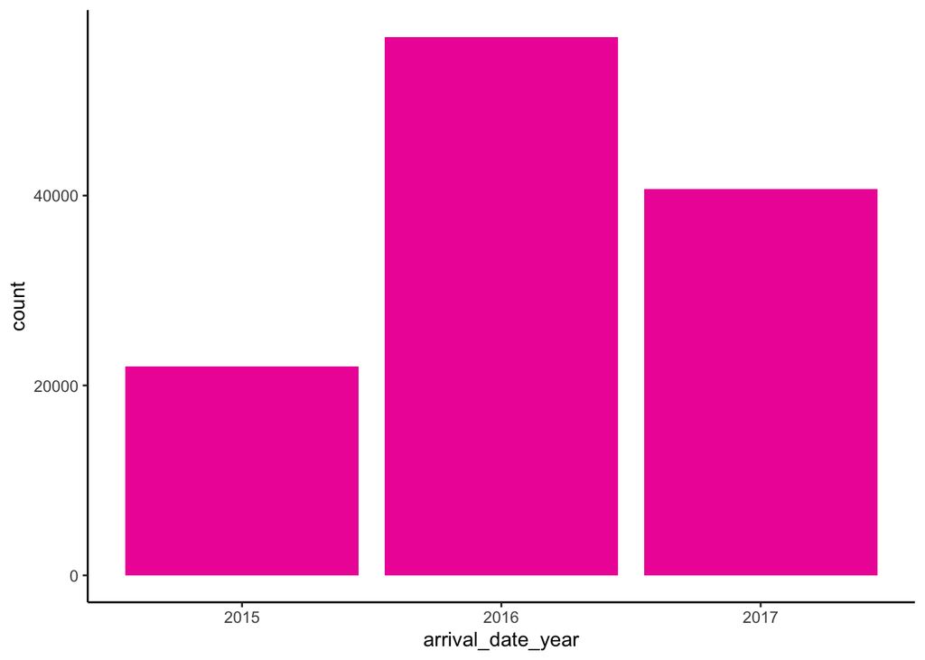

**Arrival Date Year**

*The bar shows the number of guests that booked hotels each month from 2015-2017 at the particular hotels. We can see from the graph there were highest number of bookings in August and lowest number of bookings in January.*

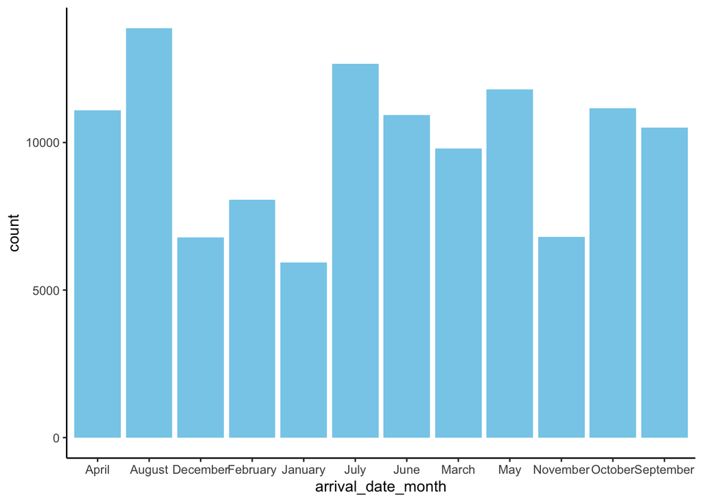

**Preference in Month**

*From this graph, we can see that guests overall preferred the City Hotel over Resort*

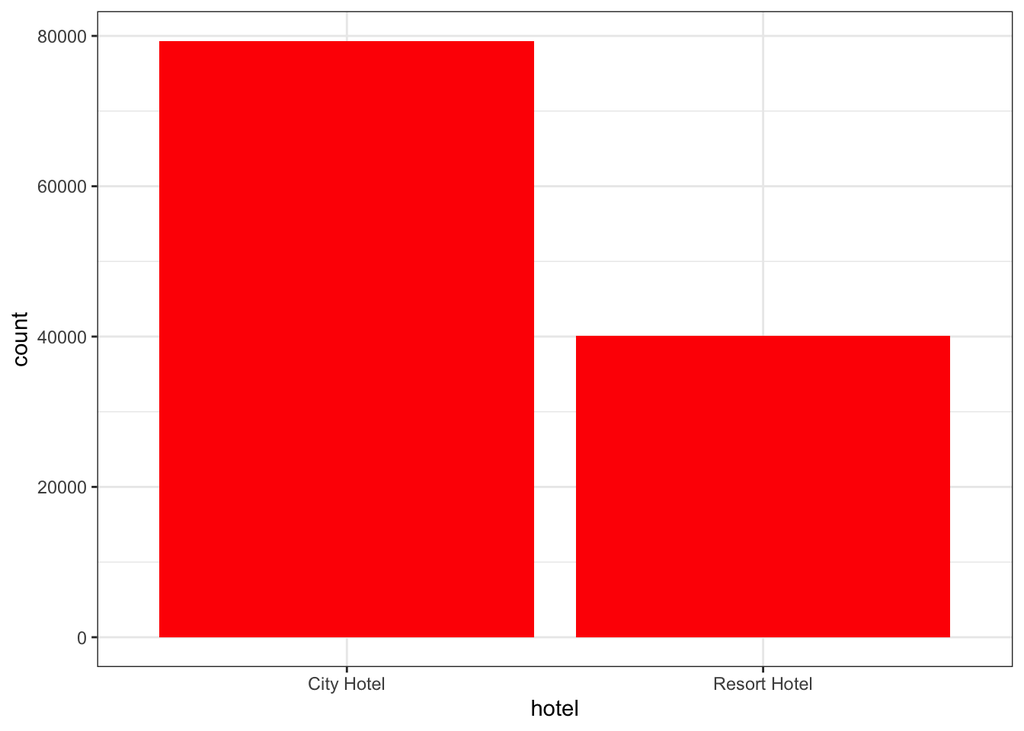

**Preference in Hotel** **Filter Database**

**Arrange Database**

```
## # A tibble: 6 x 3
## # Groups:   hotel, arrival_date_year [6]
##   hotel        arrival_date_year     n
##   <chr>                    <dbl> <int>
## 1 City Hotel                2015 13682
## 2 City Hotel                2016 38140
## 3 City Hotel                2017 27508
## 4 Resort Hotel              2015  8314
## 5 Resort Hotel              2016 18567
## 6 Resort Hotel              2017 13179
```

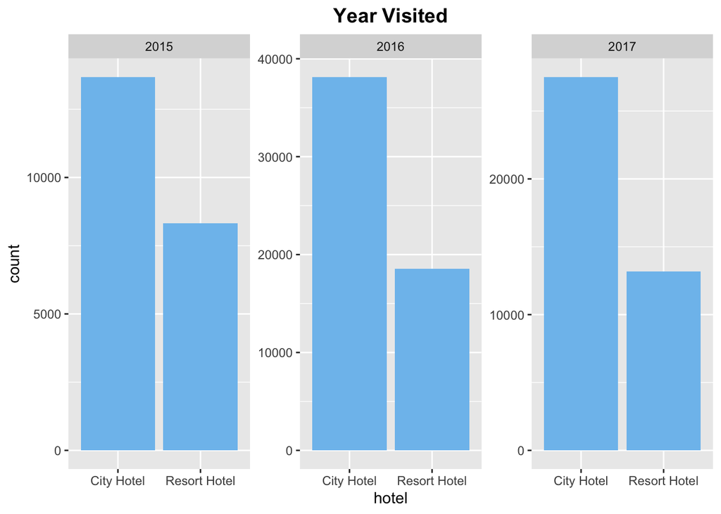

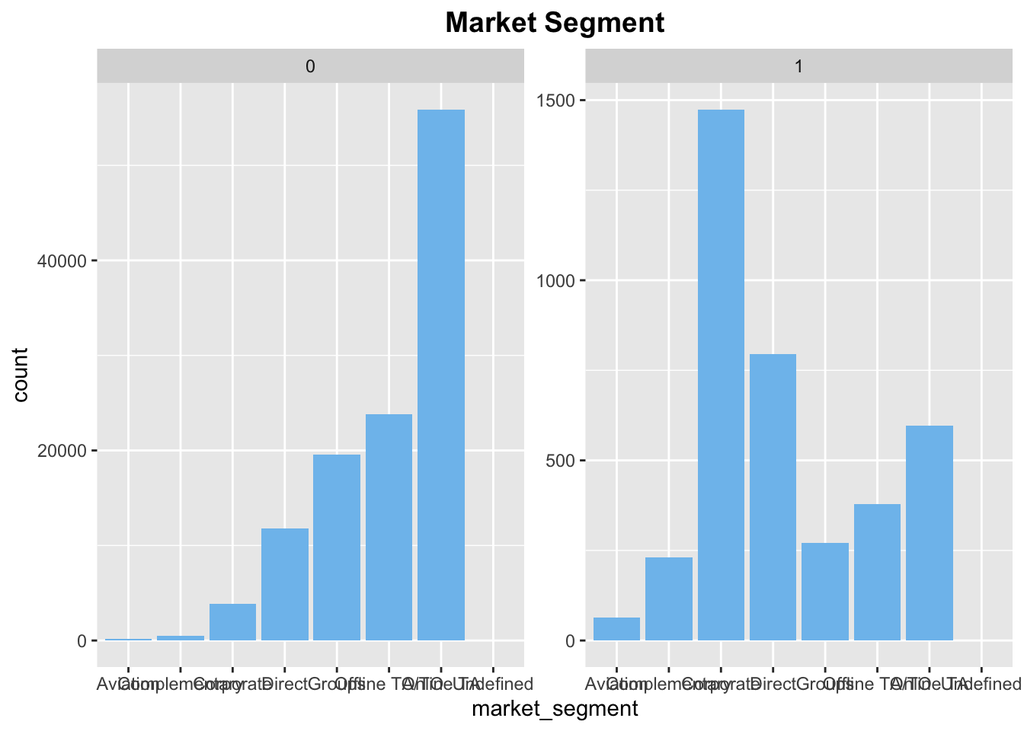

```
## # A tibble: 4 x 3
## # Groups:   hotel, is_repeated_guest [4]
##   hotel        is_repeated_guest     n
##   <chr>                    <dbl> <int>
## 1 City Hotel                   0 77298
## 2 City Hotel                   1  2032
## 3 Resort Hotel                 0 38282
## 4 Resort Hotel                 1  1778
```

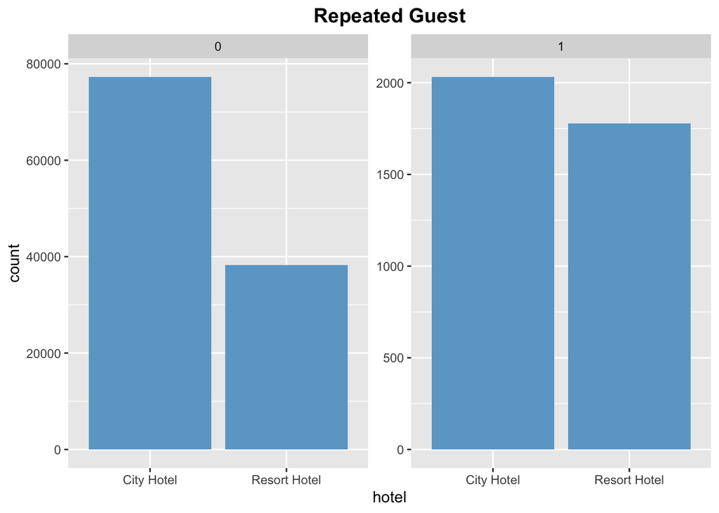

```
## # A tibble: 6 x 3
## # Groups:   arrival_date_year, is_repeated_guest [6]
##   arrival_date_year is_repeated_guest     n
##               <dbl>             <dbl> <int>
## 1              2015                 0 21355
## 2              2015                 1   641
## 3              2016                 0 54929
## 4              2016                 1  1778
## 5              2017                 0 39296
## 6              2017                 1  1391
```

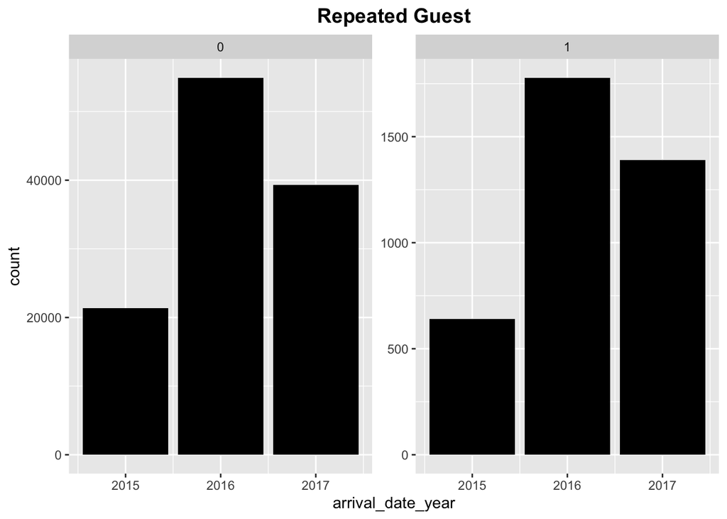

*The graph shows the number of repeated guests in each city hotel and resort hotel, you can also see in the number of repeated guests each year.

```
## # A tibble: 26 x 3
## # Groups:   arrival_date_year, arrival_date_month [26]
##    arrival_date_year arrival_date_month     n
##                <dbl> <chr>              <int>
##  1              2015 August              3889
##  2              2015 December            2920
##  3              2015 July                2776
##  4              2015 November            2340
##  5              2015 October             4957
##  6              2015 September           5114
##  7              2016 April               5428
##  8              2016 August              5063
##  9              2016 December            3860
## 10              2016 February            3891
## # … with 16 more rows
```

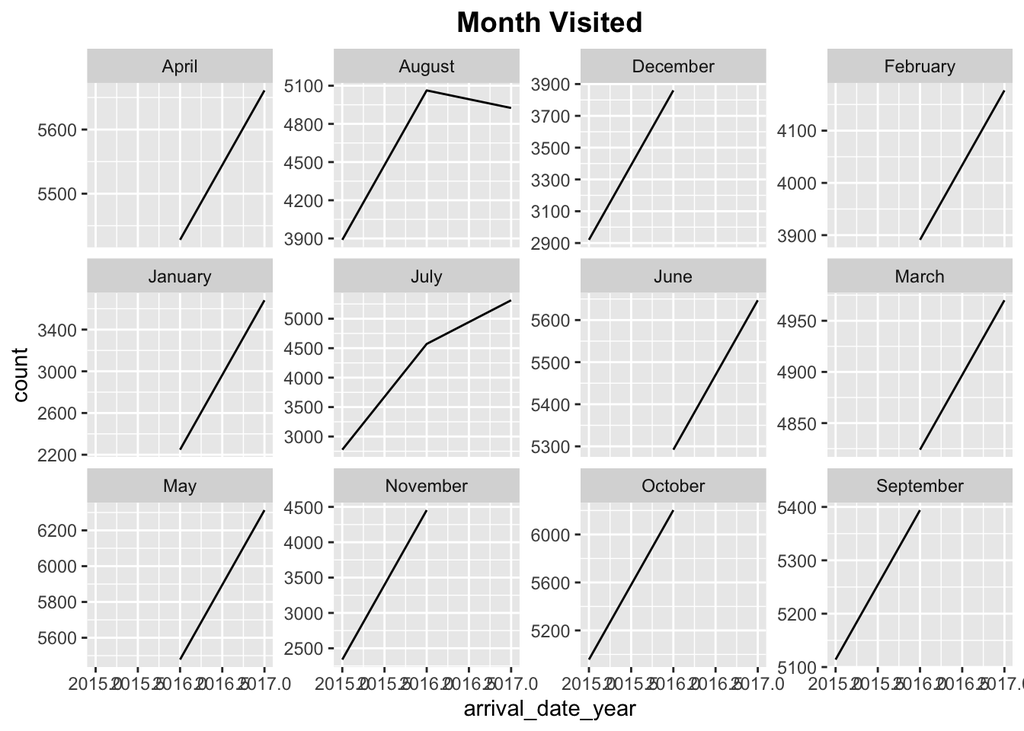

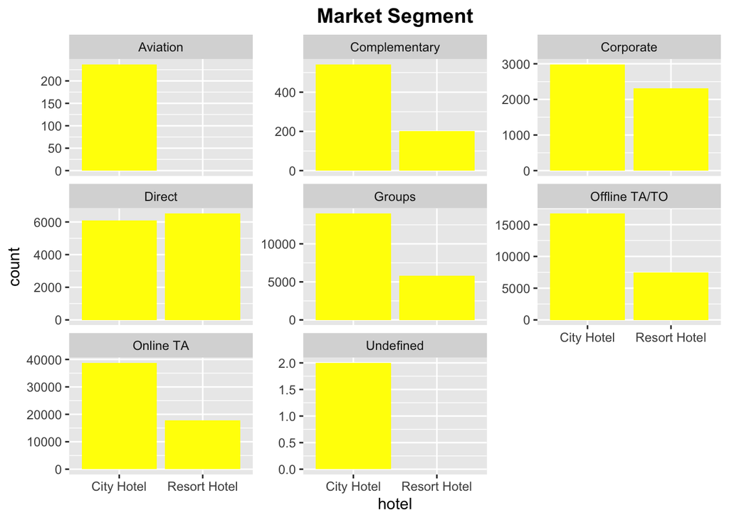

**Reflection**

*This project was my initial introduction to R and rstudio projects, therefore when I was working through understanding the concepts there were some roadblocks. However, the data set that I had selected “hotel_bookings” was a fairly advanced and straightforward dataset. It helped to complete this assignment in chunks spread out through the three weeks as I was able to identify my issues easily and work accordingly. The initial difficulty I had with the paper was in github as I was not able to identify my directory and connect it to the main repository. This created an error in R where the most important section “Read in Data” was not running. Without establishing this connection further analysis was not possible. I learned that in order to have your data in the code we have to establish the connection by piping the data to the necessary assigned folders. Once I was able to code the connection the error was removed*

**References**

*Hotel Booking Demand (February 2019.) https://www.kaggle.com/jessemostipak/hotel-booking-demand*

*Qualitative study of online hotel booking systems (Henry, 2018) https://pmworldlibrary.net/wp-content/uploads/2018/03/pmwj68-Mar2018-Henry-study-of-online-booking-systems-student-paper.pdf*

*US Travel Association (2021) https://www.ustravel.org/answersheet*